# Icelandic Vegetation is Changing

March 2026

## What this study is about

### **Has the plant life changed?**

The short answer is: **yes, and in ways that are consistent enough to measure.**

## The dataset at a glance

| Plots revisited | 163 |
| --- | --- |
| Total species records | 5374 |
| Unique plant taxa | 226 |
| Shortest gap between surveys | 9 years |
| Longest gap between surveys | 25 years |
| Median gap | 12 years |

Each plot is compared to **itself** — first survey vs. last survey.  
This removes the noise of plots being in different places or climates.

## Finding 1 — Species richness has shifted

Most plots did not stay the same.

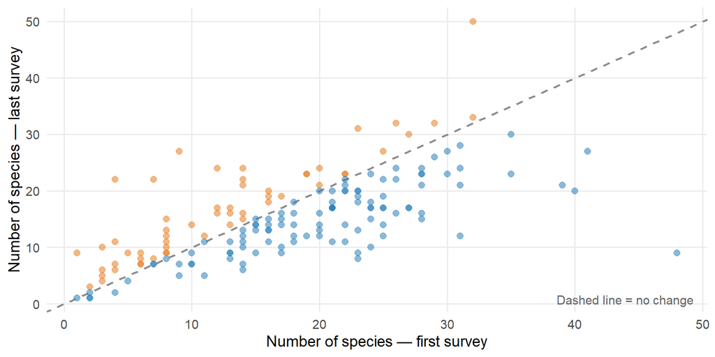

Points **above** the line = more species now. Points **below** = fewer.

## Finding 1 — How much did richness change?

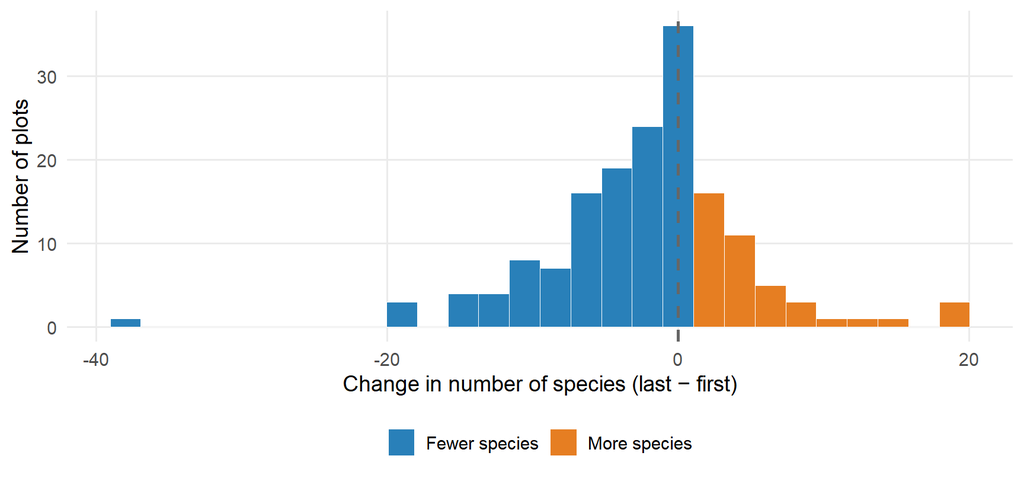

## Finding 2 — Diversity (not just count) also changed

Species richness only counts how many species are present.  
**Shannon diversity** also weighs how evenly they share the space.

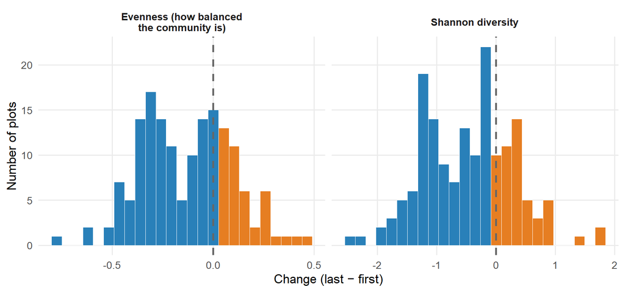

Median Shannon change: **-0.397** · Median evenness change: **-0.111**

## Finding 3 — Total plant cover changed too

Not just which species are there — but how much vegetation there is overall.

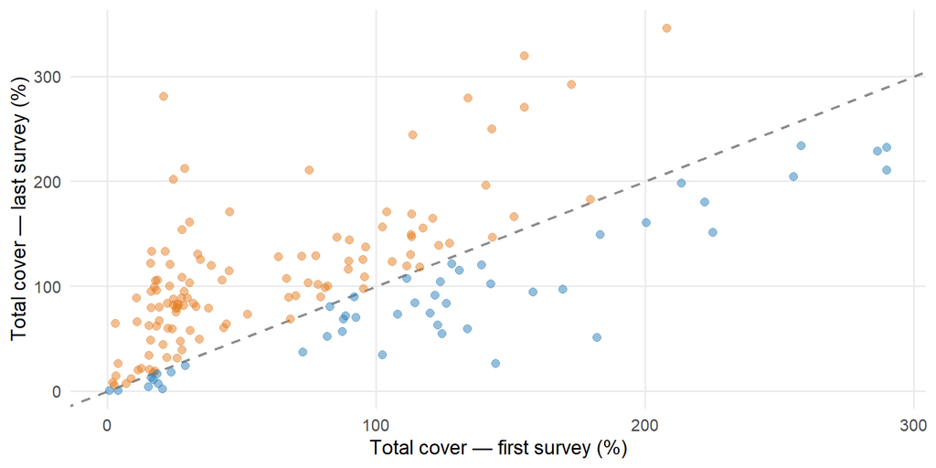

Points above the line = more plant cover now.

## Finding 4 — The dominant species are different now

The plants that **dominated** a plot in the first survey are often **not the same ones** dominating in the last.

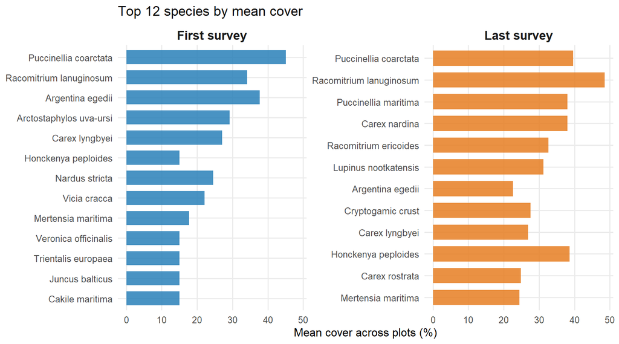

## Finding 5 — The composition of whole communities shifted

Bray-Curtis dissimilarity measures how different a plot’s species list is between surveys.  
**0 = identical. 1 = nothing in common.**

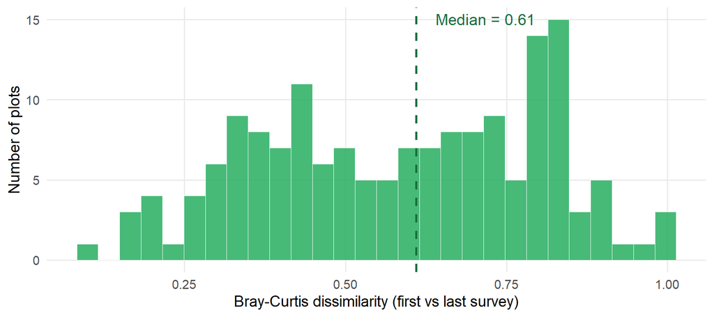

A median of **0.61** means the typical plot has changed substantially.

## Finding 6 — Community change is statistically real

We tested whether the difference between first and last surveys is larger than  
what we’d expect by chance alone, while controlling for each plot’s identity.

| Test | R² | F | p-value |
| --- | --- | --- | --- |
| Paired PERMANOVA (999 permutations) | 0.0273 | 8.99 | 0.001 |

> **Plain language:** The first-vs-last difference is real, not random noise.  
> It’s small (R² = 2.7%) but highly consistent across plots.

## Finding 7 — Which environmental factors matter most?

We fitted environmental variables onto the ordination (envfit).  
Variables with longer arrows explain more of the community pattern.

Variable

r²

p

Type

soil_depth

0.321

0.001

continuous

soil_type_name

0.345

0.001

categorical

moisture_name

0.223

0.001

categorical

topography_name

0.021

0.043

categorical

permafrost

0.006

0.175

ns

categorical

## Finding 7 — The ordination map

Each dot is one survey of one plot. Lines connect the **same plot** across time.  
Arrows point toward increasing values of environmental variables.

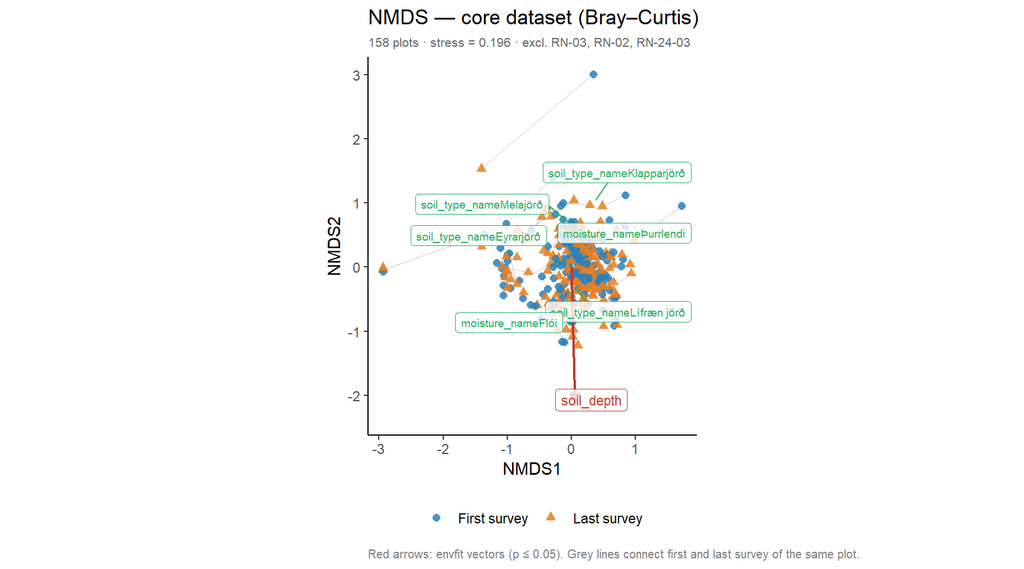

**IndVal analysis** identifies taxa that are consistently more common in  
either the first or the last survey across all plots.

[figure not shown]

## What is driving the change?

> These findings are correlational. A designed resurvey with climate and land-use  
> data alongside would let us test *why* communities are shifting.

## Summary

[output not shown]

> **Bottom line:** Icelandic vegetation plots have changed between surveys in  
> ways that are consistent, measurable, and not explained by random variation.

## Next steps

**Short term — squeeze more from this dataset**

- Add survey-gap as a covariate: does more time = more change?
- Split analysis by soil type to ask which habitats are most vulnerable
- Spatial analysis: is change clustered geographically?

**Longer term — if new fieldwork is possible**

- Resurvey a subset of plots with standardised protocol
- Collect paired climate / land-use covariates
- Move from “did it change?” to “why did it change?”

## Methods in brief

[output not shown]